# CRISPRa ERV-W differential expression analysis of genes

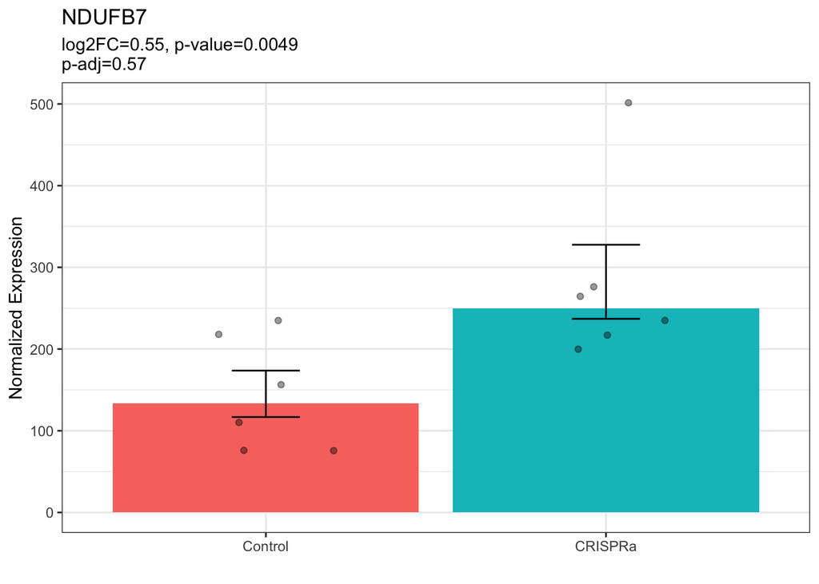

```r
barplot_gene_e01213_dpi30("NDUFB7")
```

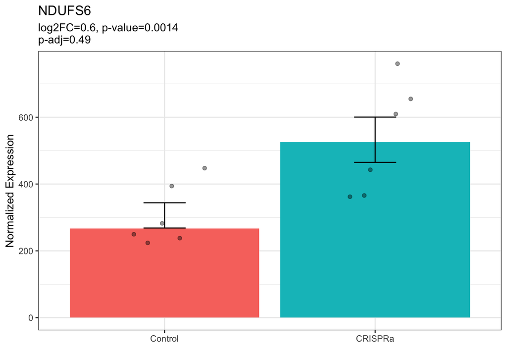

```r
barplot_gene_e01213_dpi30("NDUFS6")
```

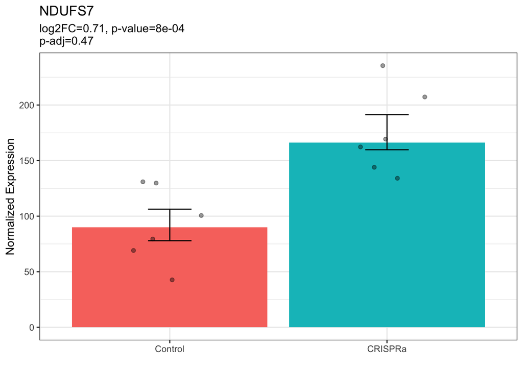

```r
barplot_gene_e01213_dpi30("NDUFS7")
```

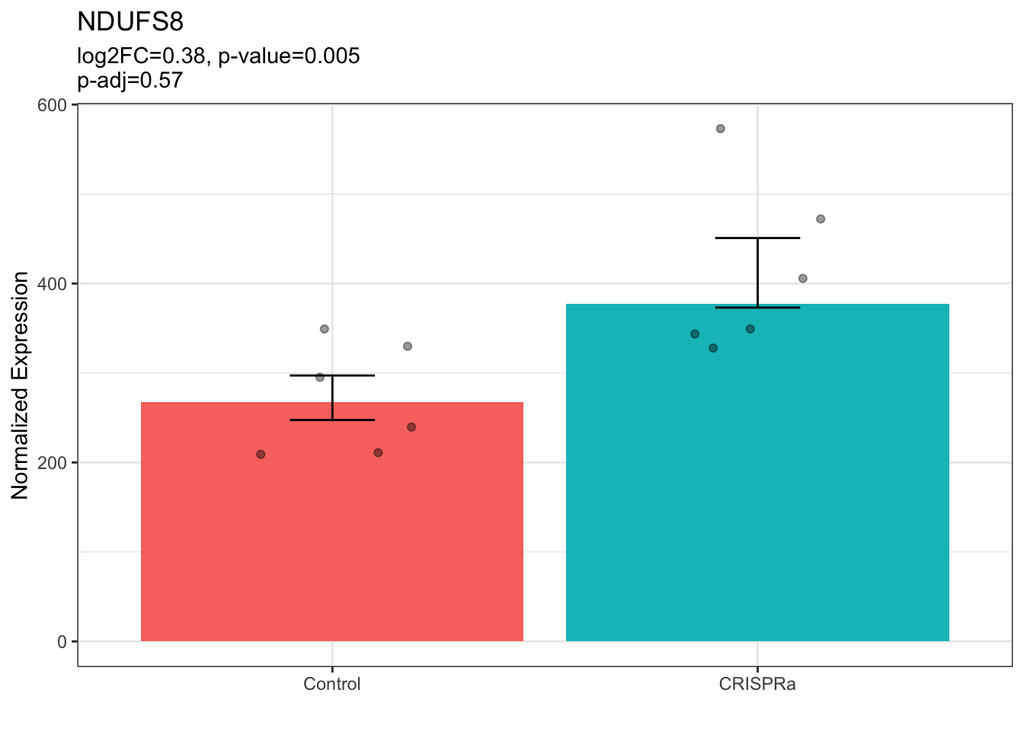

```r
barplot_gene_e01213_dpi30("NDUFS8")
```

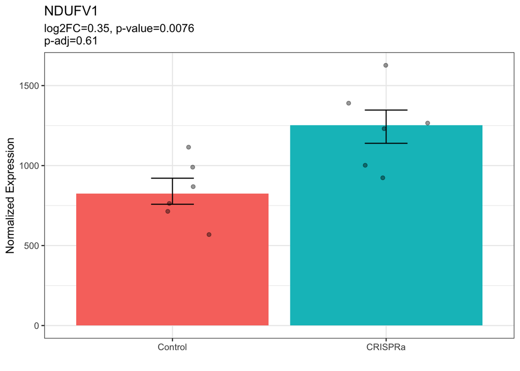

```r
barplot_gene_e01213_dpi30("NDUFV1")
```

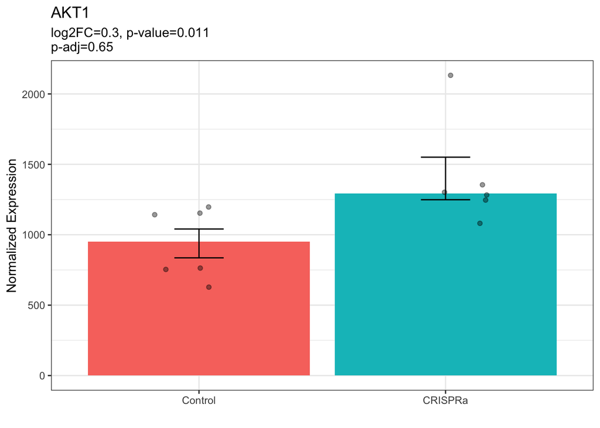

```r
barplot_gene_e01213_dpi30("AKT1")
```

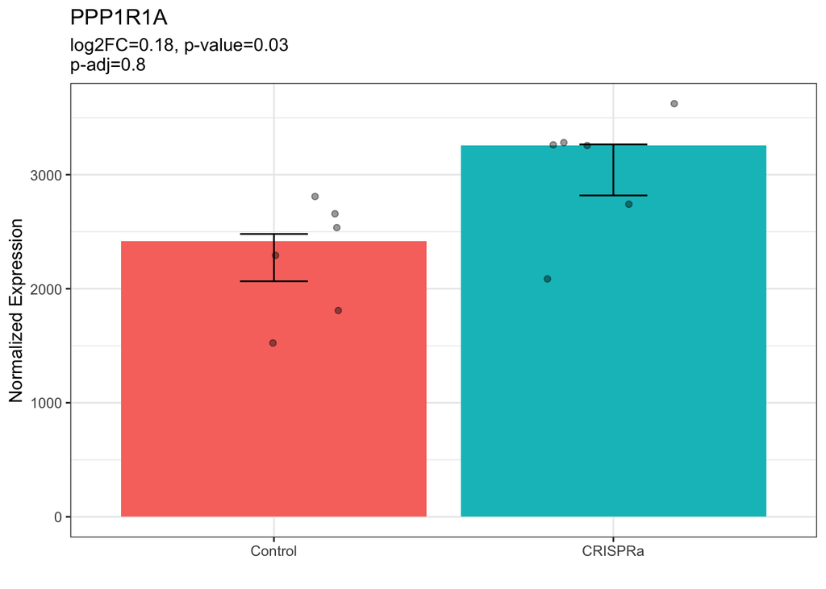

```r
barplot_gene_e01213_dpi30("PPP1R1A")
```

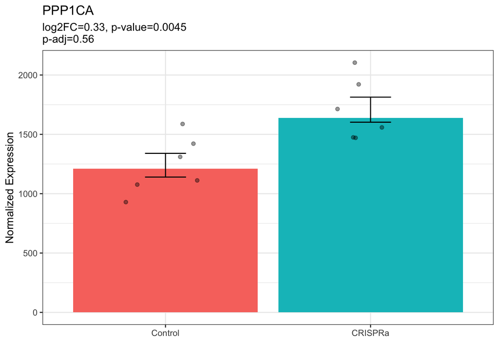

```r
barplot_gene_e01213_dpi30("PPP1CA")
```

## Is it syncytin?

We can compare ERV-W CRISPRa with Syncytin CRISPRa on day 30 iNGNs

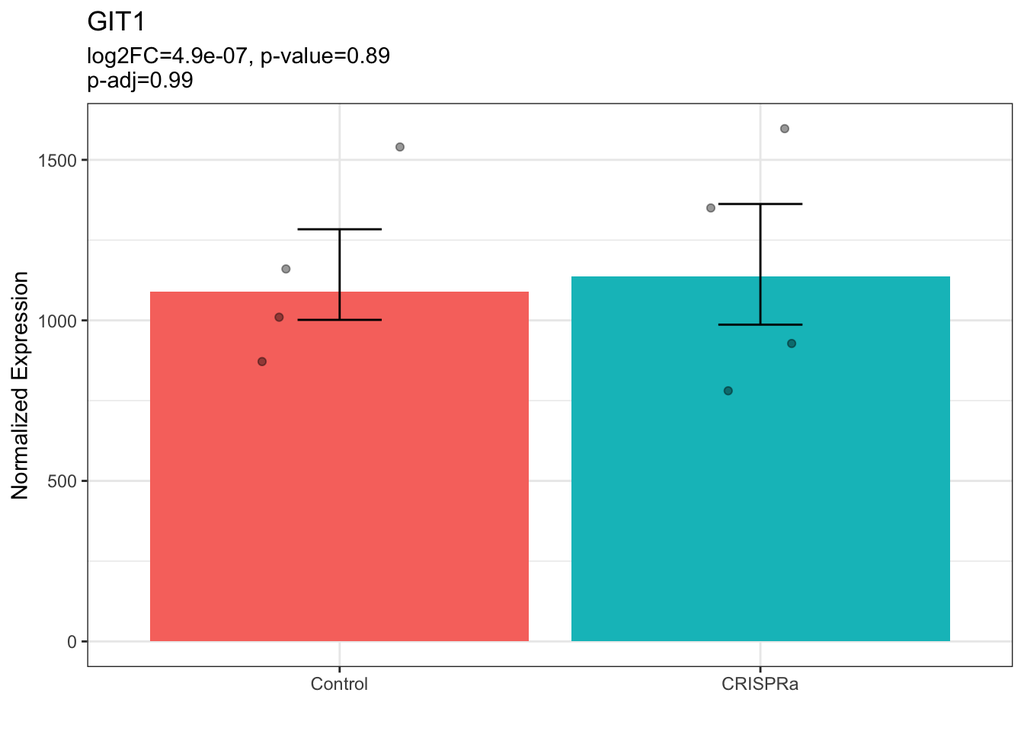

```r
gene_counts_norm_syn_day30 <- gene_counts[, samplesheet_Ca_LV4070_E01213_30dpi$sample ]
gene_counts_norm_syn_day30[] <- mapply(gene_counts_norm_syn_day30, gene_dds_list$Ca_LV4070_E01213_30dpi$sizeFactor,  FUN="/")
rownames(gene_counts_norm_syn_day30) <- rownames(gene_counts)

gene_res_list_df$Ca_LV4070_E01213_30dpi$gene <- rownames(gene_res_list_df$Ca_LV4070_E01213_30dpi)

barplot_gene_e013_dpi30 <- function(gene){
  return(gene_counts_norm_syn_day30[gene,] %>%
           rownames_to_column("gene") %>%
           pivot_longer(-gene) %>%
           rename(sample = name) %>%
           left_join(samplesheet_Ca_LV4070_E01213_30dpi) %>%
           left_join(gene_res_list_df$Ca_LV4070_E01213_30dpi) %>%
           ggplot(aes(x=condition, fill = condition, y=value)) +
           stat_summary(fun = median, geom="bar") +
           stat_summary( fun.data = mean_se, geom = "errorbar", width=0.2) +
           geom_jitter(width = 0.2, alpha=0.4) +
           labs(y="Normalized Expression", x="") +
           ggtitle(gene, subtitle = paste0("log2FC=", format(gene_res_list_df$Ca_LV4070_E01213_30dpi[gene, "log2FoldChange"], digits=2),
                                           ", p-value=", format(gene_res_list_df$Ca_LV4070_E01213_30dpi[gene, "pvalue"], digits=2),
                                           "\np-adj=", format(gene_res_list_df$Ca_LV4070_E01213_30dpi[gene, "padj"], digits=2))) +
           theme_bw() + theme(legend.position = "None"))
}

barplot_gene_e013_dpi30("GIT1")
```

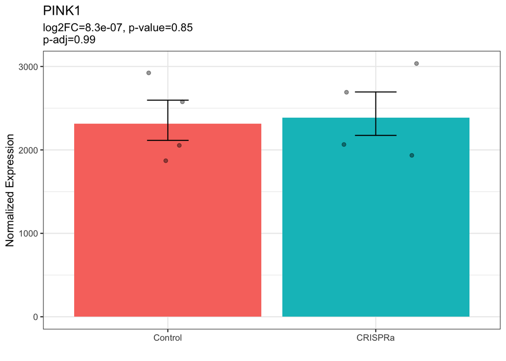

```r
barplot_gene_e013_dpi30("PINK1")
```

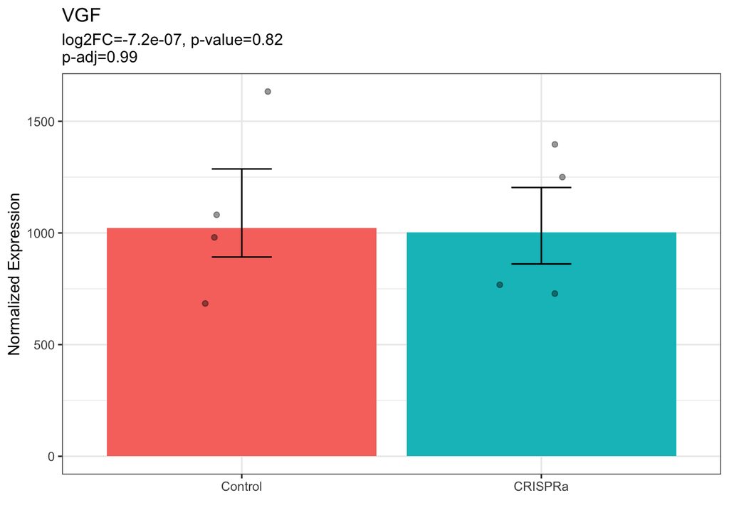

```r
barplot_gene_e013_dpi30("VGF")
```

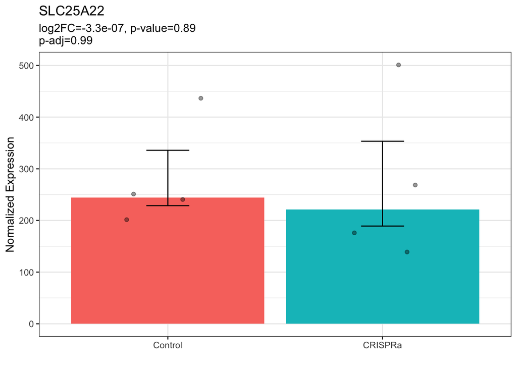

```r
barplot_gene_e013_dpi30("SLC25A22")
```

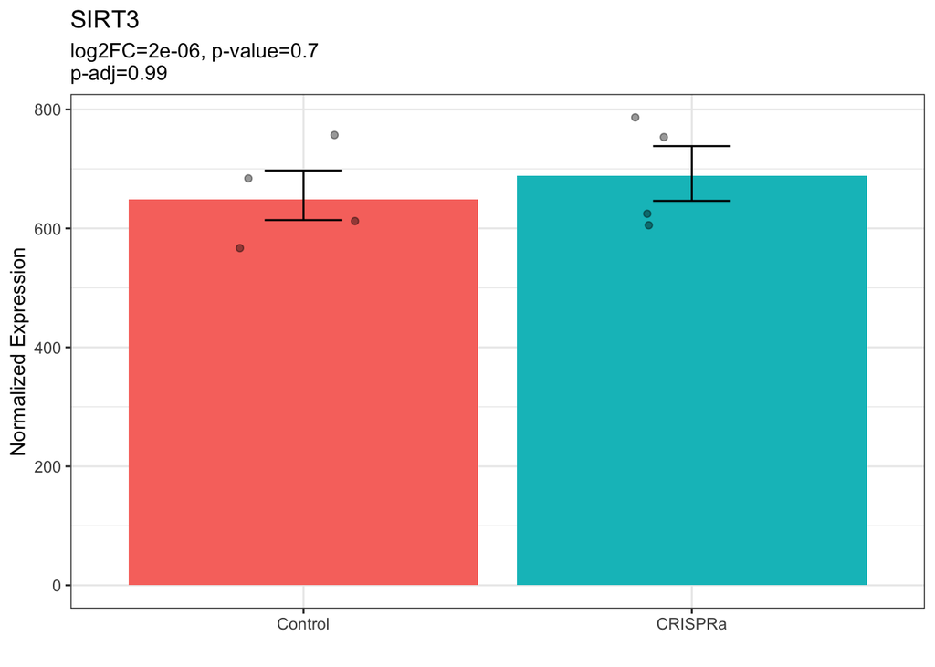

```r
barplot_gene_e013_dpi30("SIRT3")
```

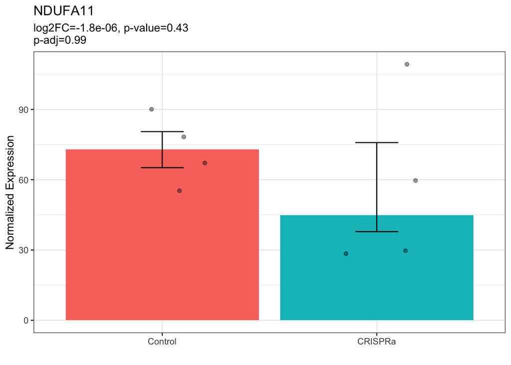

```r
barplot_gene_e013_dpi30("NDUFA11")
```

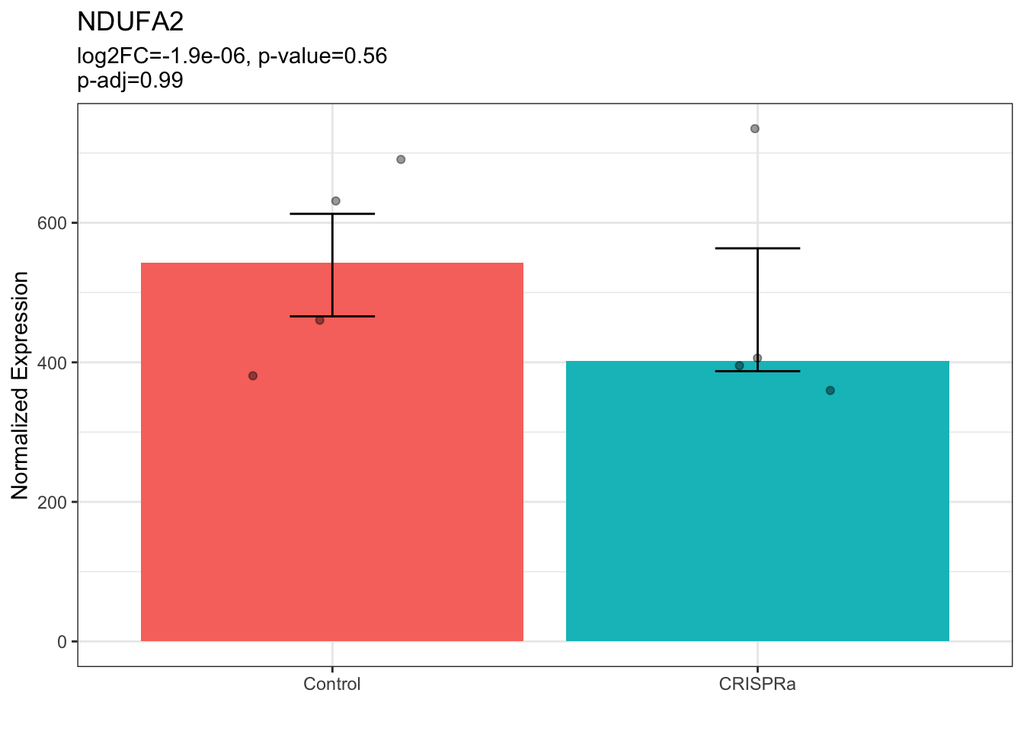

```r
barplot_gene_e013_dpi30("NDUFA2")
```

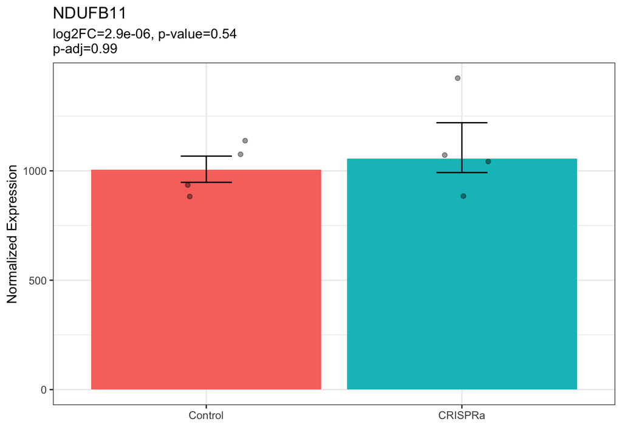

```r
barplot_gene_e013_dpi30("NDUFB11")
```

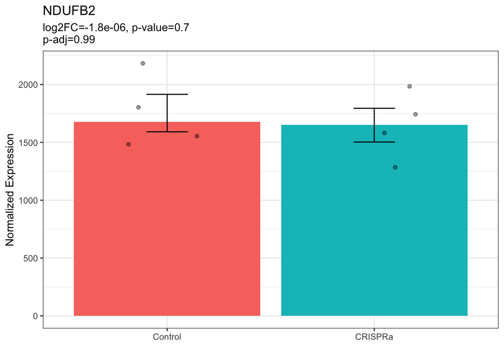

```r
barplot_gene_e013_dpi30("NDUFB2")
```

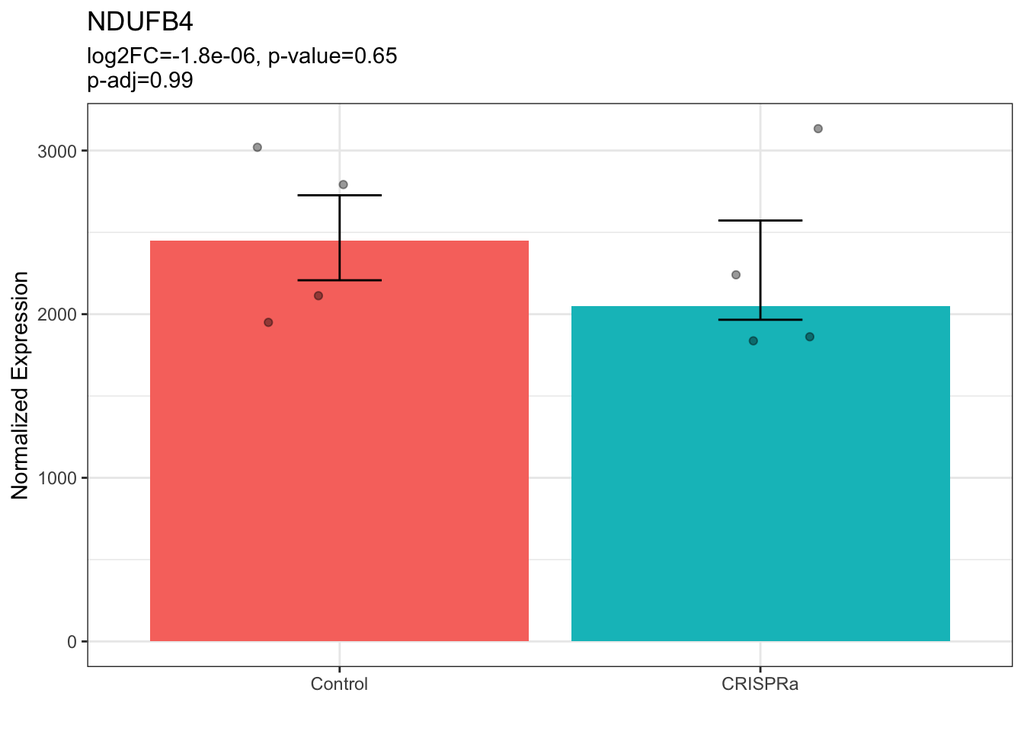

```r
barplot_gene_e013_dpi30("NDUFB4")
```

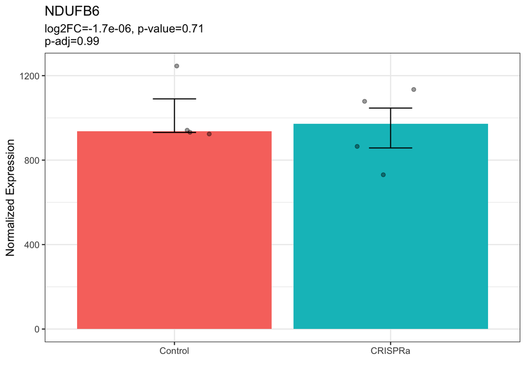

```r
barplot_gene_e013_dpi30("NDUFB6")
```

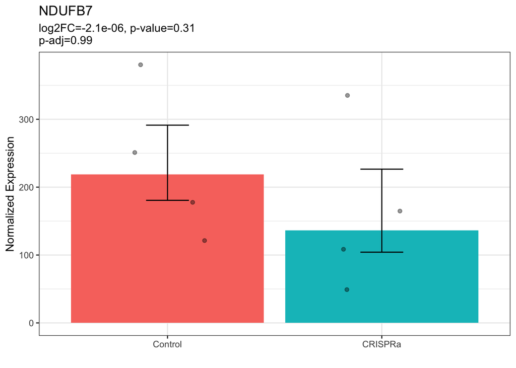

```r
barplot_gene_e013_dpi30("NDUFB7")
```

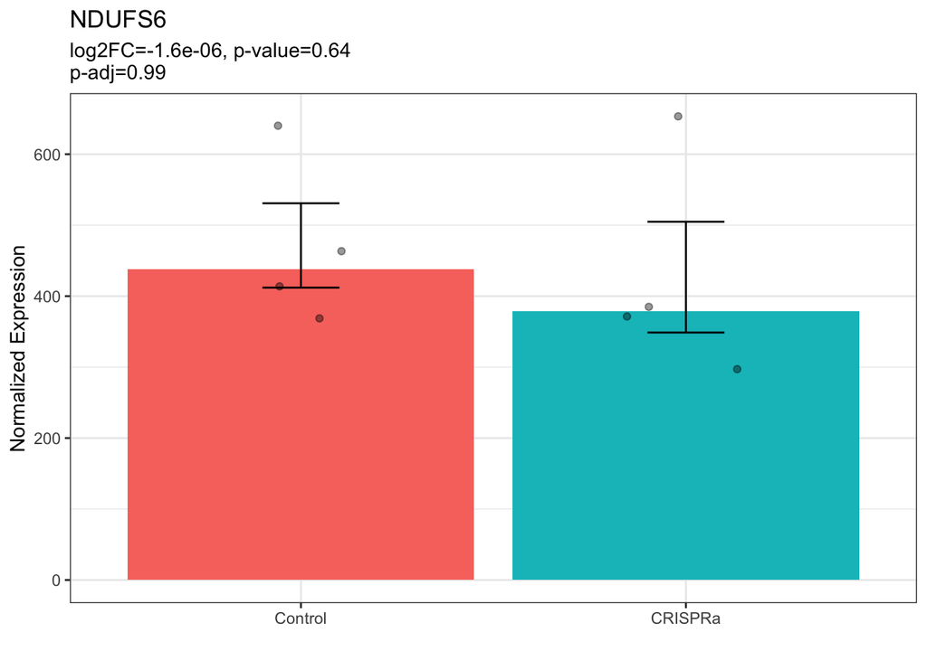

```r
barplot_gene_e013_dpi30("NDUFS6")
```

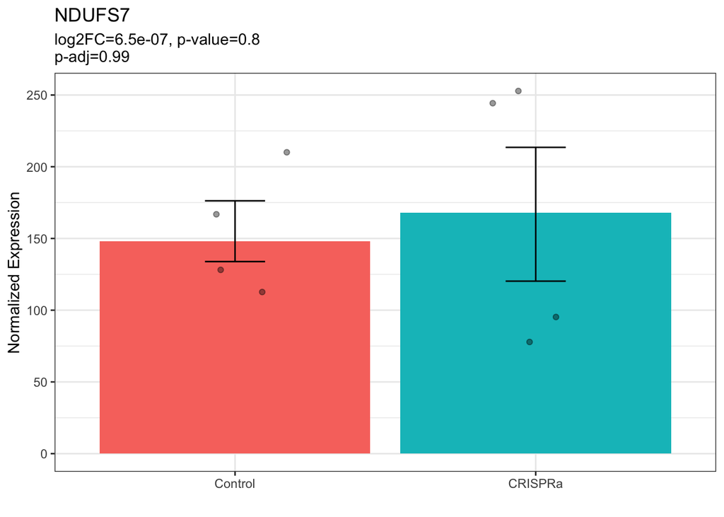

```r
barplot_gene_e013_dpi30("NDUFS7")
```

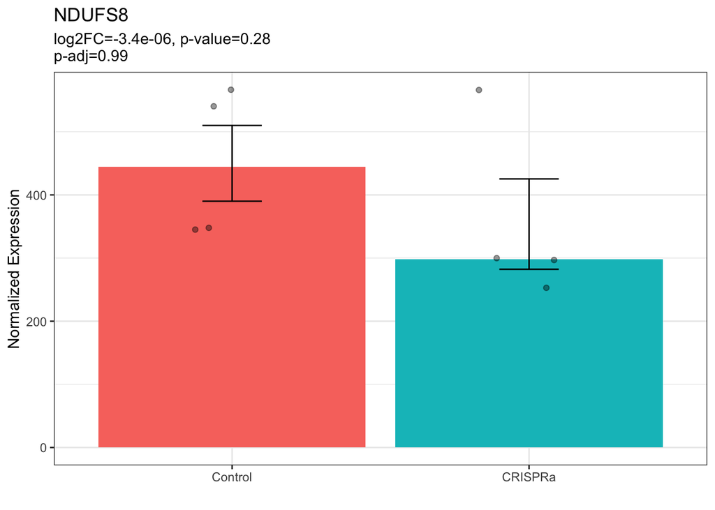

```r
barplot_gene_e013_dpi30("NDUFS8")
```

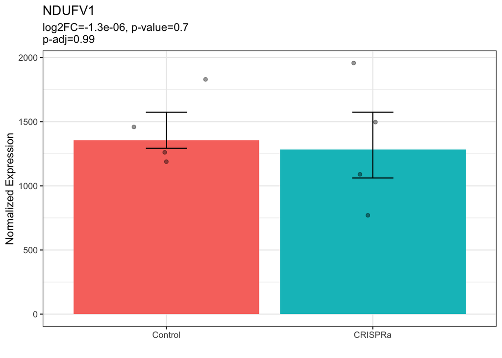

```r
barplot_gene_e013_dpi30("NDUFV1")
```

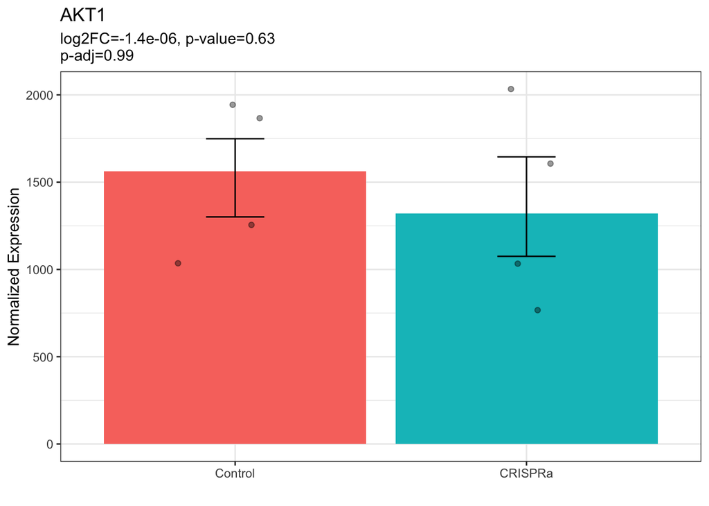

```r
barplot_gene_e013_dpi30("AKT1")
```

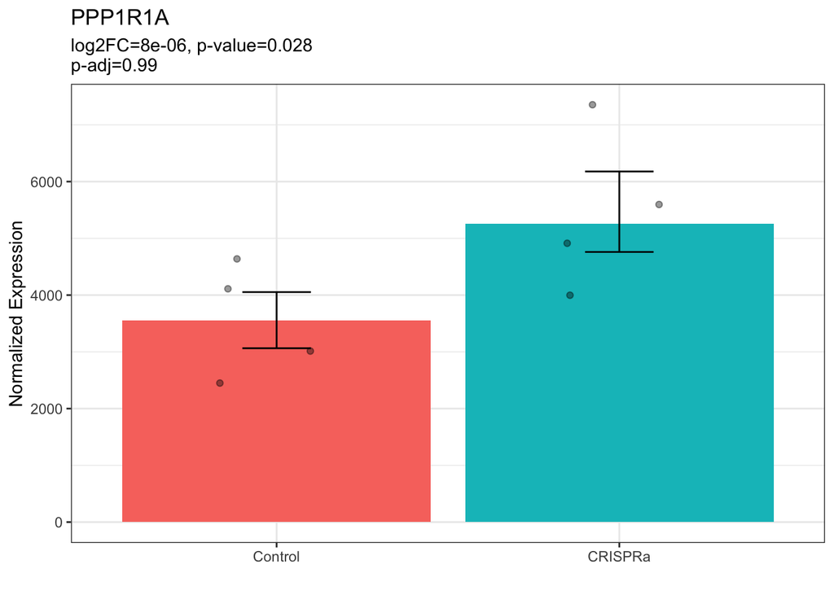

```r
barplot_gene_e013_dpi30("PPP1R1A")
```

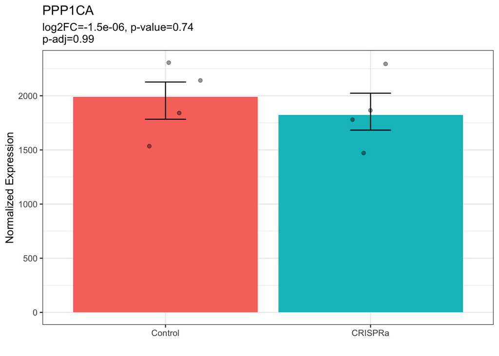

```r
barplot_gene_e013_dpi30("PPP1CA")
```

## Correlation of energy related genes between ERV-W CRISPRa and syncytin CRISPRa

Are ANY of these core enrichment genes up in the syncytin CRISPRa?

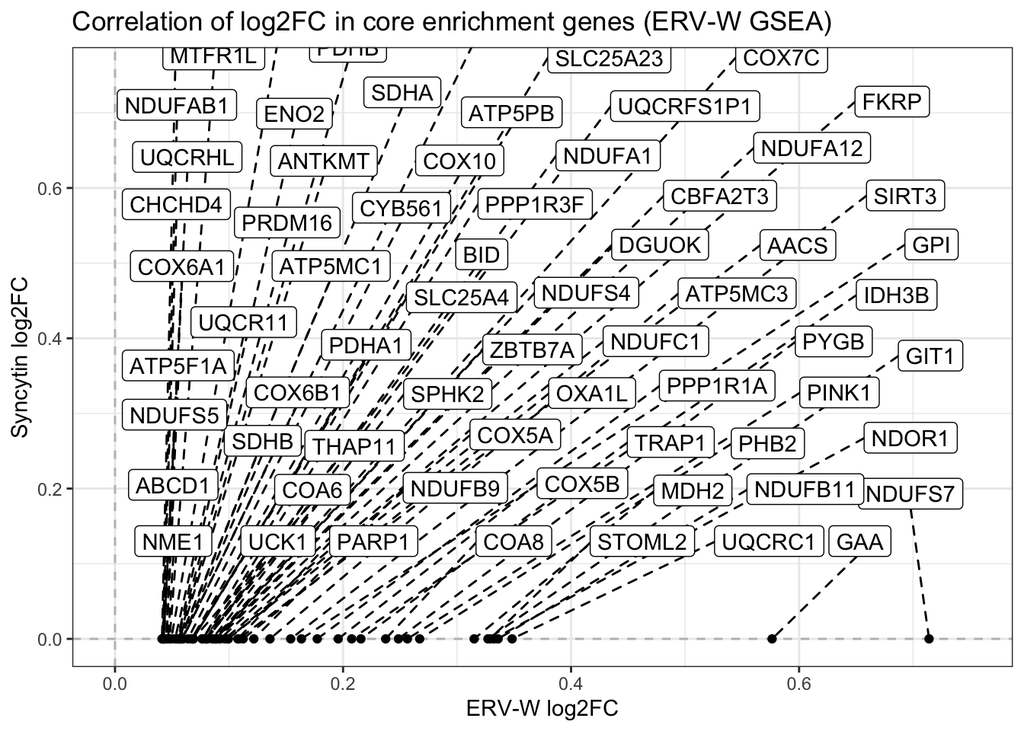

```r
gene_res_list_df$Ca_LV4009_E01213_30dpi[unique(unlist(str_split(gse_list_df$Ca_LV4009_E01213_30dpi$core_enrichment, "/"))),] %>%
  rename("LV4009_log2FC" = log2FoldChange) %>%
  dplyr::select(LV4009_log2FC, gene_name) %>%
  left_join(gene_res_list_df$Ca_LV4070_E01213_30dpi[unique(unlist(str_split(gse_list_df$Ca_LV4009_E01213_30dpi$core_enrichment, "/"))), ]) %>%
  rename("LV4070_log2FC" = log2FoldChange) %>%
  dplyr::select(LV4009_log2FC, LV4070_log2FC, gene_name) %>%
  ggplot(aes(x=LV4009_log2FC, y=LV4070_log2FC, label=gene_name)) +
  lims(x=c(0,0.75), y=c(0,0.75)) +
  geom_hline(yintercept = 0, linetype="dashed", color="grey") +
  geom_vline(xintercept = 0, linetype="dashed", color="grey") +
  geom_point() +
  geom_label_repel(max.overlaps = 100, seed = 1, ylim = c(0.1,2), force = 100, xlim = c(0,0.75), segment.linetype = "dashed") +
  theme_bw() + labs(x="ERV-W log2FC", y="Syncytin log2FC") +
  ggtitle("Correlation of log2FC in core enrichment genes (ERV-W GSEA)")
```

## Gene expression changes in relation to proximity to an ERV-W: Day 30 iNGNs

Does gene expression changes upon CRISPRa of ERV-W in neurons?

```r
path <- "./data/LTR17_distance_bin_day30/" # Output dir
dir.create(path)
protein_coding_genes <- fread("./data/gencode.v38.annotation_protein_coding_genes.bed", skip=1)
colnames(protein_coding_genes) <- c("chr", "start", "end", "gene", "dot", "strand")

# Set gene names as rownames
gene_res_list_df$Ca_LV4009_E01213_30dpi$gene <- rownames(gene_res_list_df$Ca_LV4009_E01213_30dpi)

# Extract all protein coding genes from the results
protein_coding_genes$log2FC <- gene_res_list_df$Ca_LV4009_E01213_30dpi[protein_coding_genes$gene, "log2FoldChange"]

# Make a bed to intersect to ERV-Ws
write.table(protein_coding_genes, "./data/LTR17_distance_bin_day30/gene_DEA_Ca_LV4009_E01213_30dpi_protein_coding.bed", sep="\t", quote = F, row.names = F, col.names = F)
```

## Intersection of protein coding gene promoters with ERV-Ws

1. Extract TSS of the genes

```bash
awk '{if($6=="+"){print $1,$2,$2+1,$4,$5,$6,$7}else{print $1,$3-1,$3,$4,$5,$6,$7}}' OFS="\t" ./data/LTR17_distance_bin_day30/gene_DEA_Ca_LV4009_E01213_30dpi_protein_coding.bed > ./data/LTR17_distance_bin_day30/gene_DEA_Ca_LV4009_E01213_30dpi_protein_coding_TSS.bed
```

2. Intersect with LTR17s (since this is the family we made the guides towards)

Within 1000 bps (`bedtools window -w 1000`), 5000 bps (`bedtools window -w 5000`), etc

```bash
bedtools window -a ./data/hg38_rmsk_TEtranscripts_LTR17.bed -b ./data/LTR17_distance_bin_day30/gene_DEA_Ca_LV4009_E01213_30dpi_protein_coding_TSS.bed -w 1000 -bed > ./data/LTR17_distance_bin_day30/gene_DEA_Ca_LV4009_E01213_30dpi_protein_coding_TSS_w1kbp_LTR17.bed

bedtools window -a ./data/hg38_rmsk_TEtranscripts_LTR17.bed -b ./data/LTR17_distance_bin_day30/gene_DEA_Ca_LV4009_E01213_30dpi_protein_coding_TSS.bed -w 5000 -bed > ./data/LTR17_distance_bin_day30/gene_DEA_Ca_LV4009_E01213_30dpi_protein_coding_TSS_w5kbp_LTR17.bed

bedtools window -a ./data/hg38_rmsk_TEtranscripts_LTR17.bed -b ./data/LTR17_distance_bin_day30/gene_DEA_Ca_LV4009_E01213_30dpi_protein_coding_TSS.bed -w 10000 -bed > ./data/LTR17_distance_bin_day30/gene_DEA_Ca_LV4009_E01213_30dpi_protein_coding_TSS_w10kbp_LTR17.bed

bedtools window -a ./data/hg38_rmsk_TEtranscripts_LTR17.bed -b ./data/LTR17_distance_bin_day30/gene_DEA_Ca_LV4009_E01213_30dpi_protein_coding_TSS.bed -w 15000 -bed > ./data/LTR17_distance_bin_day30/gene_DEA_Ca_LV4009_E01213_30dpi_protein_coding_TSS_w15kbp_LTR17.bed

bedtools window -a ./data/hg38_rmsk_TEtranscripts_LTR17.bed -b ./data/LTR17_distance_bin_day30/gene_DEA_Ca_LV4009_E01213_30dpi_protein_coding_TSS.bed -w 25000 -bed > ./data/LTR17_distance_bin_day30/gene_DEA_Ca_LV4009_E01213_30dpi_protein_coding_TSS_w25kbp_LTR17.bed

bedtools window -a ./data/hg38_rmsk_TEtranscripts_LTR17.bed -b ./data/LTR17_distance_bin_day30/gene_DEA_Ca_LV4009_E01213_30dpi_protein_coding_TSS.bed -w 50000 -bed > ./data/LTR17_distance_bin_day30/gene_DEA_Ca_LV4009_E01213_30dpi_protein_coding_TSS_w50kbp_LTR17.bed
```

### Visualize the results

Load the data

```r
files <- list.files(path)
files <- files[which(grepl("w1kbp_LTR17|w5kbp_LTR17|w10kbp_LTR17|w15kbp_LTR17|w25kbp_LTR17|w50kbp_LTR17", files))]
files
```

```
## [1] "gene_DEA_Ca_LV4009_E01213_30dpi_protein_coding_TSS_w10kbp_LTR17.bed"
## [2] "gene_DEA_Ca_LV4009_E01213_30dpi_protein_coding_TSS_w15kbp_LTR17.bed"
## [3] "gene_DEA_Ca_LV4009_E01213_30dpi_protein_coding_TSS_w1kbp_LTR17.bed"
## [4] "gene_DEA_Ca_LV4009_E01213_30dpi_protein_coding_TSS_w25kbp_LTR17.bed"
## [5] "gene_DEA_Ca_LV4009_E01213_30dpi_protein_coding_TSS_w50kbp_LTR17.bed"
## [6] "gene_DEA_Ca_LV4009_E01213_30dpi_protein_coding_TSS_w5kbp_LTR17.bed"
```

```r
gene_DEA_30dpi_protein_coding_TSS_w1kbp <- fread(paste0(path, "/gene_DEA_Ca_LV4009_E01213_30dpi_protein_coding_TSS_w1kbp_LTR17.bed"))
gene_DEA_30dpi_protein_coding_TSS_w5kbp <- fread(paste0(path, "/gene_DEA_Ca_LV4009_E01213_30dpi_protein_coding_TSS_w5kbp_LTR17.bed"))
gene_DEA_30dpi_protein_coding_TSS_w10kbp <- fread(paste0(path, "/gene_DEA_Ca_LV4009_E01213_30dpi_protein_coding_TSS_w10kbp_LTR17.bed"))
gene_DEA_30dpi_protein_coding_TSS_w15kbp <- fread(paste0(path, "/gene_DEA_Ca_LV4009_E01213_30dpi_protein_coding_TSS_w15kbp_LTR17.bed"))
gene_DEA_30dpi_protein_coding_TSS_w25kbp <- fread(paste0(path, "/gene_DEA_Ca_LV4009_E01213_30dpi_protein_coding_TSS_w25kbp_LTR17.bed"))
gene_DEA_30dpi_protein_coding_TSS_w50kbp <- fread(paste0(path, "/gene_DEA_Ca_LV4009_E01213_30dpi_protein_coding_TSS_w50kbp_LTR17.bed"))

cols <- c("LTR_chr", "LTR_start", "LTR_end", "LTR_id", "LTR_dot", "LTR_strand", "LTR_info", "gene_chr", "gene_TSS_start", "gene_TSS_end", "gene", "gene_dot", "gene_strand", "gene_log2FC")

colnames(gene_DEA_30dpi_protein_coding_TSS_w1kbp) <- cols
colnames(gene_DEA_30dpi_protein_coding_TSS_w5kbp) <- cols
colnames(gene_DEA_30dpi_protein_coding_TSS_w10kbp) <- cols
colnames(gene_DEA_30dpi_protein_coding_TSS_w15kbp) <- cols
colnames(gene_DEA_30dpi_protein_coding_TSS_w25kbp) <- cols
colnames(gene_DEA_30dpi_protein_coding_TSS_w50kbp) <- cols
```

Remove duplicated entries. Namely, if a gene is in the 1kbp range, it will be in all the others too, so we want to keep it only in the closest window (1kbp).

```r
gene_DEA_30dpi_protein_coding_TSS_w50kbp <- gene_DEA_30dpi_protein_coding_TSS_w50kbp[which(!gene_DEA_30dpi_protein_coding_TSS_w50kbp$gene %in% gene_DEA_30dpi_protein_coding_TSS_w25kbp$gene),]
gene_DEA_30dpi_protein_coding_TSS_w25kbp <- gene_DEA_30dpi_protein_coding_TSS_w25kbp[which(!gene_DEA_30dpi_protein_coding_TSS_w25kbp$gene %in% gene_DEA_30dpi_protein_coding_TSS_w15kbp$gene),]
gene_DEA_30dpi_protein_coding_TSS_w15kbp <- gene_DEA_30dpi_protein_coding_TSS_w15kbp[which(!gene_DEA_30dpi_protein_coding_TSS_w15kbp$gene %in% gene_DEA_30dpi_protein_coding_TSS_w10kbp$gene),]
gene_DEA_30dpi_protein_coding_TSS_w10kbp <- gene_DEA_30dpi_protein_coding_TSS_w10kbp[which(!gene_DEA_30dpi_protein_coding_TSS_w10kbp$gene %in% gene_DEA_30dpi_protein_coding_TSS_w5kbp$gene),]
gene_DEA_30dpi_protein_coding_TSS_w5kbp <- gene_DEA_30dpi_protein_coding_TSS_w5kbp[which(!gene_DEA_30dpi_protein_coding_TSS_w5kbp$gene %in% gene_DEA_30dpi_protein_coding_TSS_w1kbp$gene),]

gene_DEA_30dpi_protein_coding_TSS_w1kbp$distance <- "w1kbp"
gene_DEA_30dpi_protein_coding_TSS_w5kbp$distance <- "w5kbp"
gene_DEA_30dpi_protein_coding_TSS_w10kbp$distance <- "w10kbp"
gene_DEA_30dpi_protein_coding_TSS_w15kbp$distance <- "w15kbp"
gene_DEA_30dpi_protein_coding_TSS_w25kbp$distance <- "w25kbp"
gene_DEA_30dpi_protein_coding_TSS_w50kbp$distance <- "w50kbp"

gene_DEA_30dpi_protein_coding_TSS <- rbind(gene_DEA_30dpi_protein_coding_TSS_w1kbp,
                                           gene_DEA_30dpi_protein_coding_TSS_w5kbp,
                                           gene_DEA_30dpi_protein_coding_TSS_w10kbp,
                                           gene_DEA_30dpi_protein_coding_TSS_w15kbp,
                                           gene_DEA_30dpi_protein_coding_TSS_w25kbp,
                                           gene_DEA_30dpi_protein_coding_TSS_w50kbp)

gene_DEA_30dpi_protein_coding_TSS$distance <- factor(gene_DEA_30dpi_protein_coding_TSS$distance, levels = c("w1kbp", "w5kbp", "w10kbp", "w15kbp", "w25kbp", "w50kbp"))
```

### Now we plot! Day 30 iNGN gene effect in relation to ERV-W LTR proximity

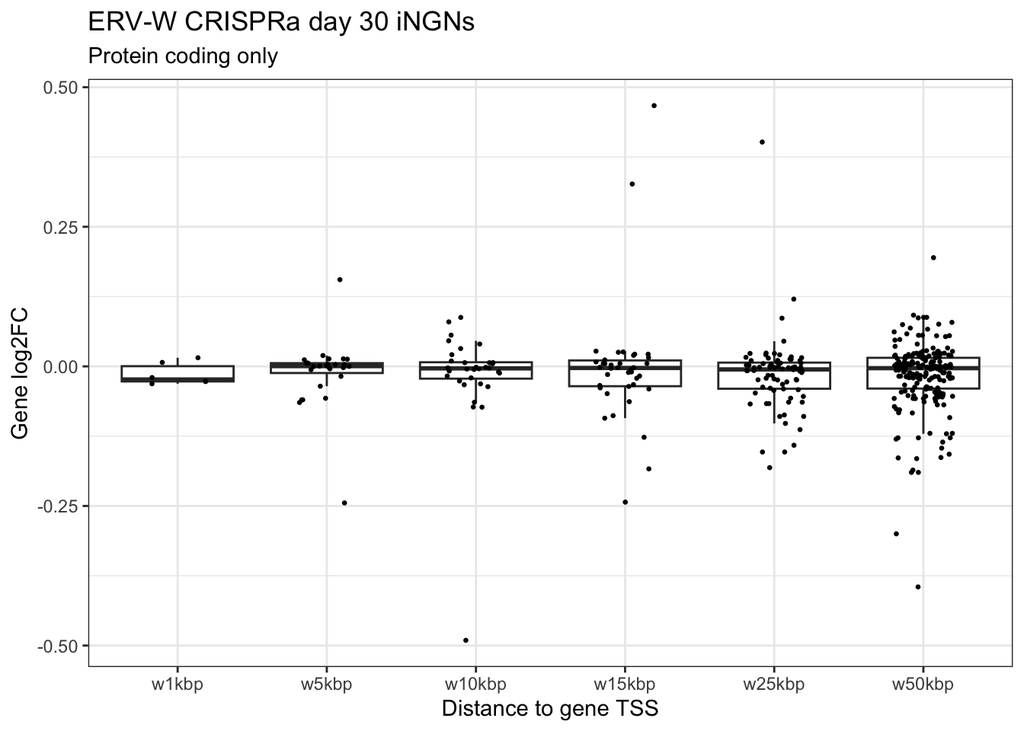

```r
gene_DEA_30dpi_protein_coding_TSS %>%
  ggplot(aes(x=distance, y=gene_log2FC)) +
  geom_boxplot(outliers = F) +
  geom_jitter(height = 0, width = 0.2, size=0.5) +
  theme_bw() +
  labs(x="Distance to gene TSS", y="Gene log2FC") + ggtitle("ERV-W CRISPRa day 30 iNGNs", subtitle = "Protein coding only")
```

## Gene expression changes in relation to proximity to an ERV-W: hiPSC

Does gene expression changes upon CRISPRa of ERV-W in hiPSC?

```r
path <- "./data/LTR17_distance_bin_hiPSC/" # Output dir
dir.create(path)
# We load again because we used that dataframe to add the log2FC before. We will do the same again but with the hiPSC results object
protein_coding_genes <- fread("./data/gencode.v38.annotation_protein_coding_genes.bed", skip=1)
colnames(protein_coding_genes) <- c("chr", "start", "end", "gene", "dot", "strand")

gene_res_list_df$Ca_LV4009_E0010405061213_0dpi$gene <- rownames(gene_res_list_df$Ca_LV4009_E0010405061213_0dpi)

protein_coding_genes$log2FC <- gene_res_list_df$Ca_LV4009_E0010405061213_0dpi[protein_coding_genes$gene, "log2FoldChange"]

write.table(protein_coding_genes, "./data/LTR17_distance_bin_hiPSC/gene_DEA_Ca_LV4009_E0010405061213_0dpi_protein_coding.bed", sep="\t", quote = F, row.names = F, col.names = F)
```

## Intersection of protein coding gene promoters with ERV-Ws

1. Extract TSS of the genes

```bash
awk '{if($6=="+"){print $1,$2,$2+1,$4,$5,$6,$7}else{print $1,$3-1,$3,$4,$5,$6,$7}}' OFS="\t" ./data/LTR17_distance_bin_hiPSC/gene_DEA_Ca_LV4009_E0010405061213_0dpi_protein_coding.bed > ./data/LTR17_distance_bin_hiPSC/gene_DEA_Ca_LV4009_E0010405061213_0dpi_protein_coding_TSS.bed
```

2. Intersect with LTR17s (since this is the family we made the guides towards)

Within 1000 bps (`bedtools window -w 1000`), 5000 bps (`bedtools window -w 5000`), etc

```bash
bedtools window -a ./data/hg38_rmsk_TEtranscripts_LTR17.bed -b ./data/LTR17_distance_bin_hiPSC/gene_DEA_Ca_LV4009_E0010405061213_0dpi_protein_coding_TSS.bed -w 1000 -bed > ./data/LTR17_distance_bin_hiPSC/gene_DEA_Ca_LV4009_E0010405061213_0dpi_protein_coding_TSS_w1kbp_LTR17.bed

bedtools window -a ./data/hg38_rmsk_TEtranscripts_LTR17.bed -b ./data/LTR17_distance_bin_hiPSC/gene_DEA_Ca_LV4009_E0010405061213_0dpi_protein_coding_TSS.bed -w 5000 -bed > ./data/LTR17_distance_bin_hiPSC/gene_DEA_Ca_LV4009_E0010405061213_0dpi_protein_coding_TSS_w5kbp_LTR17.bed

bedtools window -a ./data/hg38_rmsk_TEtranscripts_LTR17.bed -b ./data/LTR17_distance_bin_hiPSC/gene_DEA_Ca_LV4009_E0010405061213_0dpi_protein_coding_TSS.bed -w 10000 -bed > ./data/LTR17_distance_bin_hiPSC/gene_DEA_Ca_LV4009_E0010405061213_0dpi_protein_coding_TSS_w10kbp_LTR17.bed

bedtools window -a ./data/hg38_rmsk_TEtranscripts_LTR17.bed -b ./data/LTR17_distance_bin_hiPSC/gene_DEA_Ca_LV4009_E0010405061213_0dpi_protein_coding_TSS.bed -w 15000 -bed > ./data/LTR17_distance_bin_hiPSC/gene_DEA_Ca_LV4009_E0010405061213_0dpi_protein_coding_TSS_w15kbp_LTR17.bed

bedtools window -a ./data/hg38_rmsk_TEtranscripts_LTR17.bed -b ./data/LTR17_distance_bin_hiPSC/gene_DEA_Ca_LV4009_E0010405061213_0dpi_protein_coding_TSS.bed -w 25000 -bed > ./data/LTR17_distance_bin_hiPSC/gene_DEA_Ca_LV4009_E0010405061213_0dpi_protein_coding_TSS_w25kbp_LTR17.bed

bedtools window -a ./data/hg38_rmsk_TEtranscripts_LTR17.bed -b ./data/LTR17_distance_bin_hiPSC/gene_DEA_Ca_LV4009_E0010405061213_0dpi_protein_coding_TSS.bed -w 50000 -bed > ./data/LTR17_distance_bin_hiPSC/gene_DEA_Ca_LV4009_E0010405061213_0dpi_protein_coding_TSS_w50kbp_LTR17.bed
```

### Visualize the results

Load the data

```r
files <- list.files(path)
files <- files[which(grepl("w1kbp_LTR17|w5kbp_LTR17|w10kbp_LTR17|w15kbp_LTR17|w25kbp_LTR17|w50kbp_LTR17", files))]

gene_DEA_hipsc_protein_coding_TSS_w1kbp <- fread(paste0(path, "/gene_DEA_Ca_LV4009_E0010405061213_0dpi_protein_coding_TSS_w1kbp_LTR17.bed"))
gene_DEA_hipsc_protein_coding_TSS_w5kbp <- fread(paste0(path, "/gene_DEA_Ca_LV4009_E0010405061213_0dpi_protein_coding_TSS_w5kbp_LTR17.bed"))
gene_DEA_hipsc_protein_coding_TSS_w10kbp <- fread(paste0(path, "/gene_DEA_Ca_LV4009_E0010405061213_0dpi_protein_coding_TSS_w10kbp_LTR17.bed"))
gene_DEA_hipsc_protein_coding_TSS_w15kbp <- fread(paste0(path, "/gene_DEA_Ca_LV4009_E0010405061213_0dpi_protein_coding_TSS_w15kbp_LTR17.bed"))
gene_DEA_hipsc_protein_coding_TSS_w25kbp <- fread(paste0(path, "/gene_DEA_Ca_LV4009_E0010405061213_0dpi_protein_coding_TSS_w25kbp_LTR17.bed"))
gene_DEA_hipsc_protein_coding_TSS_w50kbp <- fread(paste0(path, "/gene_DEA_Ca_LV4009_E0010405061213_0dpi_protein_coding_TSS_w50kbp_LTR17.bed"))

cols <- c("LTR_chr", "LTR_start", "LTR_end", "LTR_id", "LTR_dot", "LTR_strand", "LTR_info", "gene_chr", "gene_TSS_start", "gene_TSS_end", "gene", "gene_dot", "gene_strand", "gene_log2FC")

colnames(gene_DEA_hipsc_protein_coding_TSS_w1kbp) <- cols
colnames(gene_DEA_hipsc_protein_coding_TSS_w5kbp) <- cols
colnames(gene_DEA_hipsc_protein_coding_TSS_w10kbp) <- cols
colnames(gene_DEA_hipsc_protein_coding_TSS_w15kbp) <- cols
colnames(gene_DEA_hipsc_protein_coding_TSS_w25kbp) <- cols
colnames(gene_DEA_hipsc_protein_coding_TSS_w50kbp) <- cols
```

Remove duplicated entries. Namely, if a gene is in the 1kbp range, it will be in all the others too, so we want to keep it only in the closest window (1kbp).

```r
gene_DEA_hipsc_protein_coding_TSS_w50kbp <- gene_DEA_hipsc_protein_coding_TSS_w50kbp[which(!gene_DEA_hipsc_protein_coding_TSS_w50kbp$gene %in% gene_DEA_hipsc_protein_coding_TSS_w25kbp$gene),]
gene_DEA_hipsc_protein_coding_TSS_w25kbp <- gene_DEA_hipsc_protein_coding_TSS_w25kbp[which(!gene_DEA_hipsc_protein_coding_TSS_w25kbp$gene %in% gene_DEA_hipsc_protein_coding_TSS_w15kbp$gene),]
gene_DEA_hipsc_protein_coding_TSS_w15kbp <- gene_DEA_hipsc_protein_coding_TSS_w15kbp[which(!gene_DEA_hipsc_protein_coding_TSS_w15kbp$gene %in% gene_DEA_hipsc_protein_coding_TSS_w10kbp$gene),]
gene_DEA_hipsc_protein_coding_TSS_w10kbp <- gene_DEA_hipsc_protein_coding_TSS_w10kbp[which(!gene_DEA_hipsc_protein_coding_TSS_w10kbp$gene %in% gene_DEA_hipsc_protein_coding_TSS_w5kbp$gene),]
gene_DEA_hipsc_protein_coding_TSS_w5kbp <- gene_DEA_hipsc_protein_coding_TSS_w5kbp[which(!gene_DEA_hipsc_protein_coding_TSS_w5kbp$gene %in% gene_DEA_hipsc_protein_coding_TSS_w1kbp$gene),]

gene_DEA_hipsc_protein_coding_TSS_w1kbp$distance <- "w1kbp"
gene_DEA_hipsc_protein_coding_TSS_w5kbp$distance <- "w5kbp"
gene_DEA_hipsc_protein_coding_TSS_w10kbp$distance <- "w10kbp"
gene_DEA_hipsc_protein_coding_TSS_w15kbp$distance <- "w15kbp"
gene_DEA_hipsc_protein_coding_TSS_w25kbp$distance <- "w25kbp"
gene_DEA_hipsc_protein_coding_TSS_w50kbp$distance <- "w50kbp"

gene_DEA_hipsc_protein_coding_TSS <- rbind(gene_DEA_hipsc_protein_coding_TSS_w1kbp,
                                           gene_DEA_hipsc_protein_coding_TSS_w5kbp,
                                           gene_DEA_hipsc_protein_coding_TSS_w10kbp,
                                           gene_DEA_hipsc_protein_coding_TSS_w15kbp,
                                           gene_DEA_hipsc_protein_coding_TSS_w25kbp,
                                           gene_DEA_hipsc_protein_coding_TSS_w50kbp)

gene_DEA_hipsc_protein_coding_TSS$distance <- factor(gene_DEA_hipsc_protein_coding_TSS$distance, levels = c("w1kbp", "w5kbp", "w10kbp", "w15kbp", "w25kbp", "w50kbp"))
```

### Now we plot! hiPSC gene effect in relation to ERV-W LTR proximity

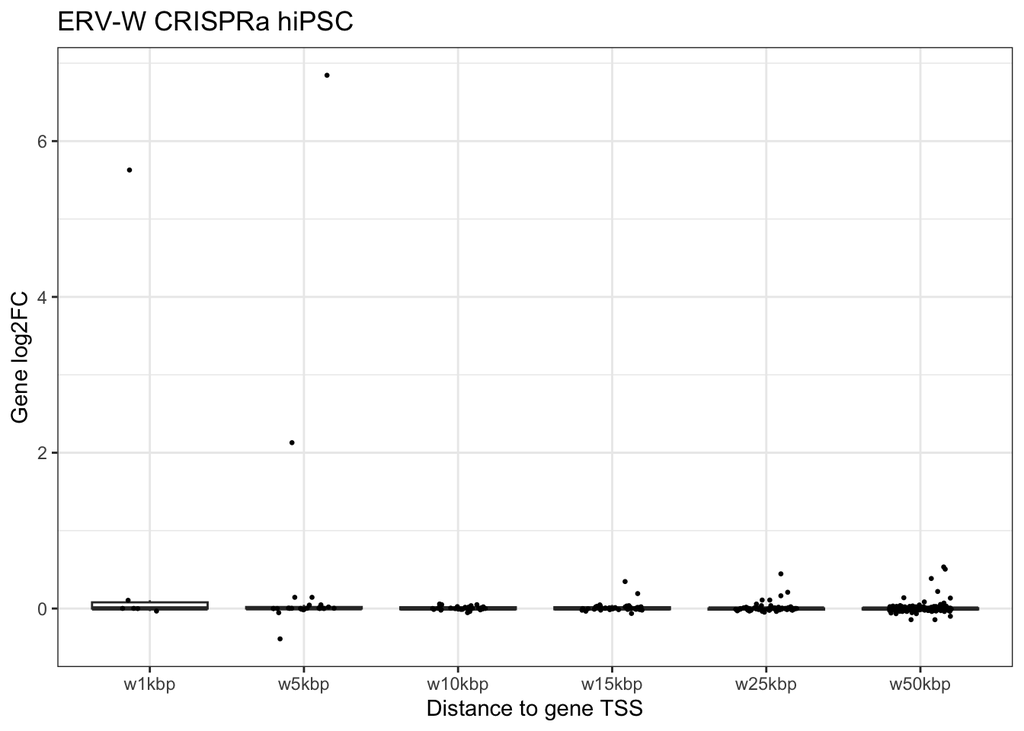

```r
gene_DEA_hipsc_protein_coding_TSS %>%
  ggplot(aes(x=distance, y=gene_log2FC)) +
  geom_boxplot(outliers = F) +
  geom_jitter(height = 0, width = 0.2, size=0.5) +
  theme_bw() +
  labs(x="Distance to gene TSS", y="Gene log2FC") + ggtitle("ERV-W CRISPRa hiPSC")
```

```r
gene_DEA_hipsc_protein_coding_TSS %>%
  filter(gene_DEA_hipsc_protein_coding_TSS$gene_log2FC > 2)
```

| LTR_chr | LTR_start | LTR_end | LTR_id | LTR_dot | LTR_strand | LTR_info | gene_chr | gene_TSS_start | gene_TSS_end | gene | gene_dot | gene_strand | gene_log2FC | distance |
| --- | --- | --- | --- | --- | --- | --- | --- | --- | --- | --- | --- | --- | --- | --- |
| chr7 | 92477413 | 92478192 | LTR17_dup404 | . | - | LTR17,ERV1,LTR | chr7 | 92477985 | 92477986 | ERVW-1 | . | - | 5.628714 | w1kbp |
| chr10 | 118599533 | 118600288 | LTR17_dup599 | . | - | LTR17,ERV1,LTR | chr10 | 118595647 | 118595648 | PRLHR | . | - | 2.128999 | w5kbp |
| chr14 | 103096412 | 103096734 | LTR17_dup739 | . | - | LTR17,ERV1,LTR | chr14 | 103100144 | 103100145 | EXOC3L4 | . | + | 6.845182 | w5kbp |